# EDA - Insurance Premium Prediction (Kaggle)

Juan Luis Castillo Giovannetty y Alejandro de Jesus Cotes Fornaris

2026-09-12

## Contexto

Dataset de la competencia de Kaggle “Regression with an Insurance Dataset” (Playground Series). Es un dataset sintetico generado con un modelo de deep learning entrenado sobre el dataset original de prediccion de primas de seguro. El target es `Premium.Amount` (continuo) y la metrica de evaluacion de la competencia es RMSLE, lo que motiva mirar tambien la escala logaritmica del target.

## Carga de datos

```r
library(tidyverse)
library(Amelia)

train <- read.csv("~/GitHub/metodos-proyecto/train.csv")
dim(train)
```

```
## [1] 1200000      21
```

```r
str(train)
```

```
## 'data.frame':    1200000 obs. of  21 variables:
##  $ id                  : int  0 1 2 3 4 5 6 7 8 9 ...
##  $ Age                 : num  19 39 23 21 21 29 41 48 21 44 ...
##  $ Gender              : chr  "Female" "Female" "Male" "Male" ...
##  $ Annual.Income       : num  10049 31678 25602 141855 39651 ...
##  $ Marital.Status      : chr  "Married" "Divorced" "Divorced" "Married" ...
##  $ Number.of.Dependents: num  1 3 3 2 1 1 0 2 3 2 ...
##  $ Education.Level     : chr  "Bachelor's" "Master's" "High School" "Bachelor's" ...
##  $ Occupation          : chr  "Self-Employed" "" "Self-Employed" "" ...
##  $ Health.Score        : num  22.6 15.6 47.2 10.9 20.4 ...
##  $ Location            : chr  "Urban" "Rural" "Suburban" "Rural" ...
##  $ Policy.Type         : chr  "Premium" "Comprehensive" "Premium" "Basic" ...
##  $ Previous.Claims     : num  2 1 1 1 0 2 2 1 1 1 ...
##  $ Vehicle.Age         : num  17 12 14 0 8 4 8 11 10 9 ...
##  $ Credit.Score        : num  372 694 NA 367 598 614 807 398 685 635 ...
##  $ Insurance.Duration  : num  5 2 3 1 4 5 6 5 8 3 ...
##  $ Policy.Start.Date   : chr  "2023-12-23 15:21:39.134960" "2023-06-12 15:21:39.111551" "2023-09-30 15:21:39.221386" "2024-06-12 15:21:39.226954" ...
##  $ Customer.Feedback   : chr  "Poor" "Average" "Good" "Poor" ...
##  $ Smoking.Status      : chr  "No" "Yes" "Yes" "Yes" ...
##  $ Exercise.Frequency  : chr  "Weekly" "Monthly" "Weekly" "Daily" ...
##  $ Property.Type       : chr  "House" "House" "House" "Apartment" ...
##  $ Premium.Amount      : num  2869 1483 567 765 2022 ...
```

```r
df <- train
```

## Limpieza previa: `""` como ausente

Varias columnas categoricas (por ejemplo `Occupation`) usan strings vacios `""` en vez de `NA`, por lo que `is.na()` no las detecta. Se normalizan antes de cualquier conteo de ausentes.

```r
df <- df |>
    mutate(across(where(is.character), ~ na_if(., "")))

numeric_vars <- c("Age", "Annual.Income", "Health.Score", "Number.of.Dependents",
                   "Previous.Claims", "Vehicle.Age", "Credit.Score", "Insurance.Duration")

categorical_vars <- c("Gender", "Marital.Status", "Education.Level", "Occupation",
                       "Location", "Policy.Type", "Customer.Feedback",
                       "Smoking.Status", "Exercise.Frequency", "Property.Type")
```

## Datos ausentes

```r
df |>
    summarise(across(everything(), ~ sum(is.na(.)), .names = "NA_{.col}"))
```

```
##   NA_id NA_Age NA_Gender NA_Annual.Income NA_Marital.Status
## 1     0  18705         0            44949             18529
##   NA_Number.of.Dependents NA_Education.Level NA_Occupation NA_Health.Score
## 1                  109672                  0        358075           74076
##   NA_Location NA_Policy.Type NA_Previous.Claims NA_Vehicle.Age NA_Credit.Score
## 1           0              0             364029              6          137882
##   NA_Insurance.Duration NA_Policy.Start.Date NA_Customer.Feedback
## 1                     1                    0                77824
##   NA_Smoking.Status NA_Exercise.Frequency NA_Property.Type NA_Premium.Amount
## 1                 0                     0                0                 0
```

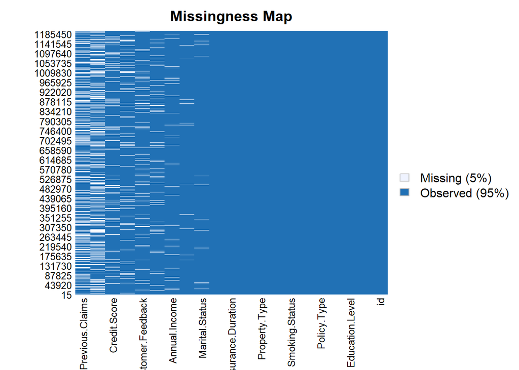

```r
missmap(df)
```

## Resumen univariado de predictores

Antes de cruzar cada variable con el target, conviene conocer su propia distribucion.

```r
summary(df[, numeric_vars])
```

```
##       Age        Annual.Income     Health.Score    Number.of.Dependents
##  Min.   :18.00   Min.   :     1   Min.   : 2.012   Min.   :0.00
##  1st Qu.:30.00   1st Qu.:  8001   1st Qu.:15.919   1st Qu.:1.00
##  Median :41.00   Median : 23911   Median :24.579   Median :2.00
##  Mean   :41.15   Mean   : 32745   Mean   :25.614   Mean   :2.01
##  3rd Qu.:53.00   3rd Qu.: 44634   3rd Qu.:34.527   3rd Qu.:3.00
##  Max.   :64.00   Max.   :149997   Max.   :58.976   Max.   :4.00
##  NAs    :18705   NAs    :44949    NAs    :74076    NAs    :109672
##  Previous.Claims   Vehicle.Age     Credit.Score    Insurance.Duration
##  Min.   :0.000    Min.   : 0.00   Min.   :300.0    Min.   :1.000
##  1st Qu.:0.000    1st Qu.: 5.00   1st Qu.:468.0    1st Qu.:3.000
##  Median :1.000    Median :10.00   Median :595.0    Median :5.000
##  Mean   :1.003    Mean   : 9.57   Mean   :592.9    Mean   :5.018
##  3rd Qu.:2.000    3rd Qu.:15.00   3rd Qu.:721.0    3rd Qu.:7.000
##  Max.   :9.000    Max.   :19.00   Max.   :849.0    Max.   :9.000
##  NAs    :364029   NAs    :6       NAs    :137882   NAs    :1
```

```r
for (v in categorical_vars) {
    cat("\n---", v, "---\n")
    print(table(df[[v]], useNA = "ifany"))
}
```

```
##
## --- Gender ---
##
## Female   Male
## 597429 602571
##
## --- Marital.Status ---
##
## Divorced  Married   Single     <NA>
##   391764   394316   395391    18529
##
## --- Education.Level ---
##
##  Bachelor's High School    Master's         PhD
##      303234      289441      303818      303507
##
## --- Occupation ---
##
##      Employed Self-Employed    Unemployed          <NA>
##        282750        282645        276530        358075
##
## --- Location ---
##
##    Rural Suburban    Urban
##   400947   401542   397511
##
## --- Policy.Type ---
##
##         Basic Comprehensive       Premium
##        398554        399600        401846
##
## --- Customer.Feedback ---
##
## Average    Good    Poor    <NA>
##  377905  368753  375518   77824
##
## --- Smoking.Status ---
##
##     No    Yes
## 598127 601873
##
## --- Exercise.Frequency ---
##
##   Daily Monthly  Rarely  Weekly
##  294571  299830  299420  306179
##
## --- Property.Type ---
##
## Apartment     Condo     House
##    399978    399673    400349
```

## Variable objetivo: `Premium.Amount`

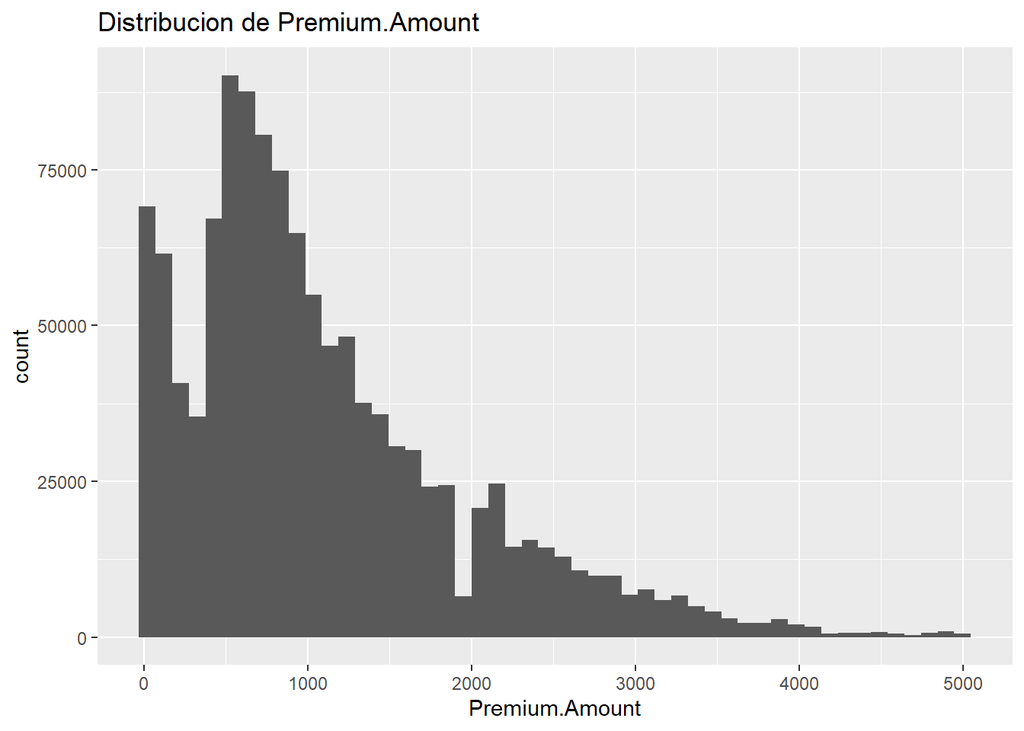

```r
ggplot(df, aes(x = Premium.Amount)) +
    geom_histogram(bins = 50) +
    labs(title = "Distribucion de Premium.Amount")
```

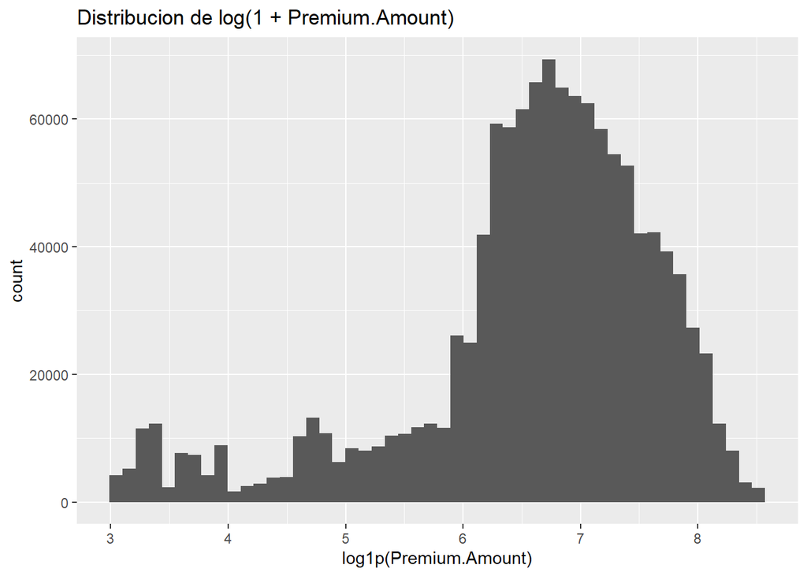

```r
ggplot(df, aes(x = log1p(Premium.Amount))) +
    geom_histogram(bins = 50) +
    labs(title = "Distribucion de log(1 + Premium.Amount)")
```

## Numericas vs target

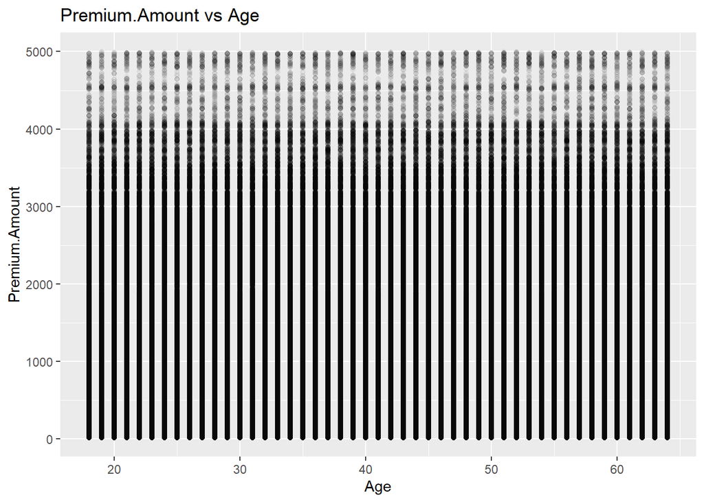

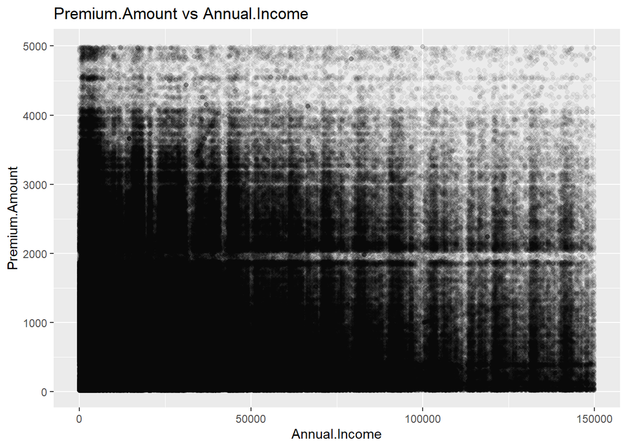

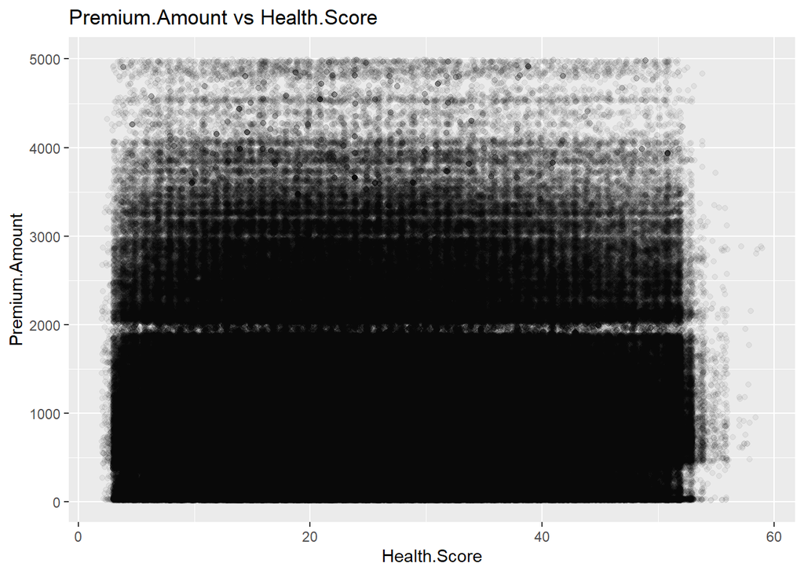

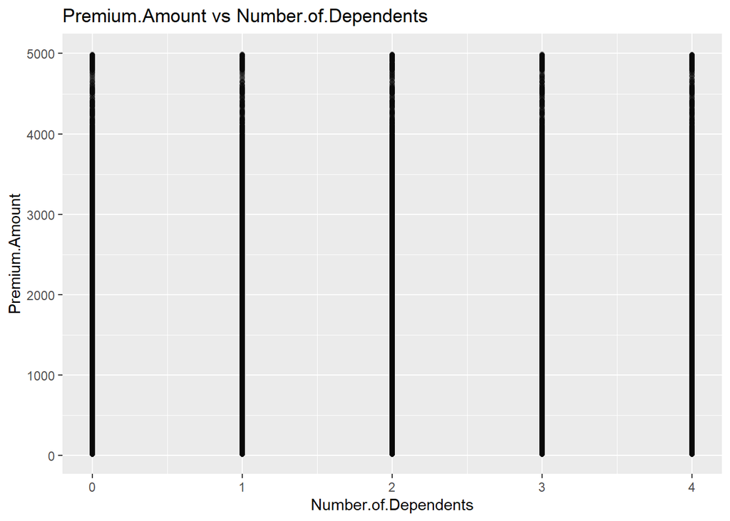

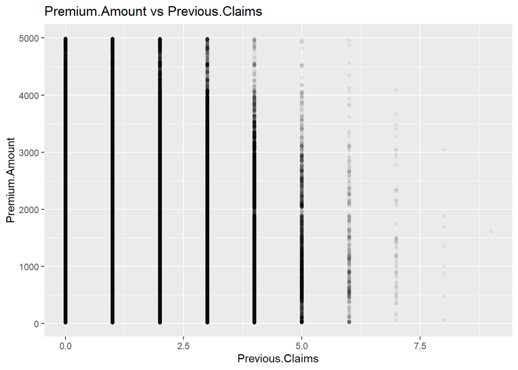

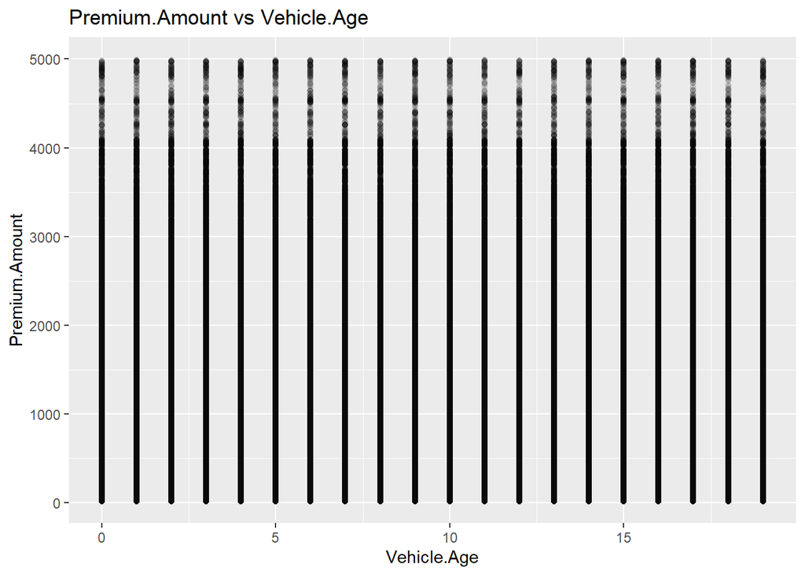

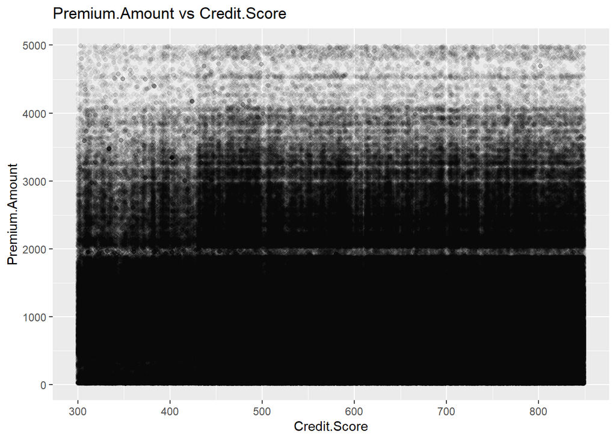

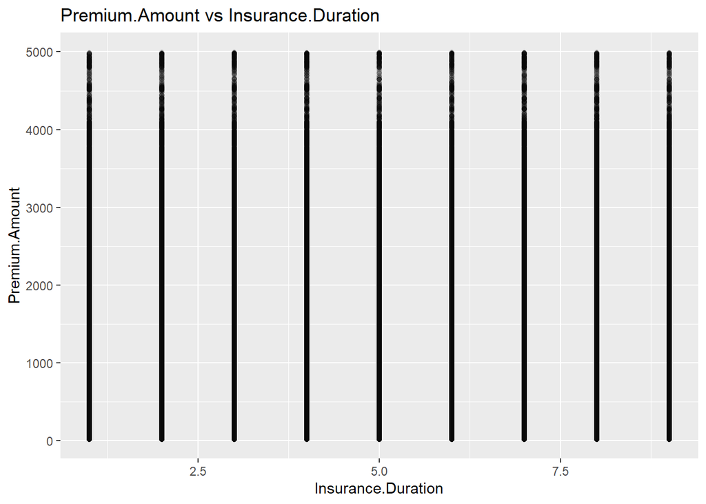

```r
for (v in numeric_vars) {
    p <- ggplot(df, aes(x = .data[[v]], y = Premium.Amount)) +
        geom_point(alpha = 0.05) +
        labs(title = paste("Premium.Amount vs", v))
    print(p)
}
```

### Correlacion entre numericas (chequeo de multicolinealidad)

```r
cor_matrix <- df |>
    select(all_of(numeric_vars), Premium.Amount) |>
    cor(use = "pairwise.complete.obs")
print(cor_matrix)
```

```
##                                Age Annual.Income Health.Score
## Age                   1.000000e+00 -9.245590e-06 0.0008808607
## Annual.Income        -9.245590e-06  1.000000e+00 0.0255302136
## Health.Score          8.808607e-04  2.553021e-02 1.0000000000
## Number.of.Dependents  1.474962e-03  2.135073e-03 0.0051524076
## Previous.Claims       1.868906e-03  4.306512e-02 0.0019894333
## Vehicle.Age          -2.455042e-03 -4.996567e-04 0.0003161318
## Credit.Score          2.841788e-03 -2.014230e-01 0.0120160087
## Insurance.Duration   -6.365050e-05  3.794905e-04 0.0024869147
## Premium.Amount       -2.430179e-03 -1.238979e-02 0.0147044918
##                      Number.of.Dependents Previous.Claims   Vehicle.Age
## Age                          0.0014749624     0.001868906 -0.0024550417
## Annual.Income                0.0021350732     0.043065117 -0.0004996567
## Health.Score                 0.0051524076     0.001989433  0.0003161318
## Number.of.Dependents         1.0000000000    -0.004122588  0.0012315629
## Previous.Claims             -0.0041225884     1.000000000 -0.0011718109
## Vehicle.Age                  0.0012315629    -0.001171811  1.0000000000
## Credit.Score                -0.0017141777     0.036816195  0.0005077457
## Insurance.Duration          -0.0002649629     0.003000509  0.0031323408
## Premium.Amount              -0.0009763042     0.046873831  0.0003909549
##                       Credit.Score Insurance.Duration Premium.Amount
## Age                   0.0028417877      -6.365050e-05  -2.430179e-03
## Annual.Income        -0.2014229892       3.794905e-04  -1.238979e-02
## Health.Score          0.0120160087       2.486915e-03   1.470449e-02
## Number.of.Dependents -0.0017141777      -2.649629e-04  -9.763042e-04
## Previous.Claims       0.0368161951       3.000509e-03   4.687383e-02
## Vehicle.Age           0.0005077457       3.132341e-03   3.909549e-04
## Credit.Score          1.0000000000       4.934166e-04  -2.601371e-02
## Insurance.Duration    0.0004934166       1.000000e+00  -2.818978e-05
## Premium.Amount       -0.0260137128      -2.818978e-05   1.000000e+00
```

## Categoricas vs target

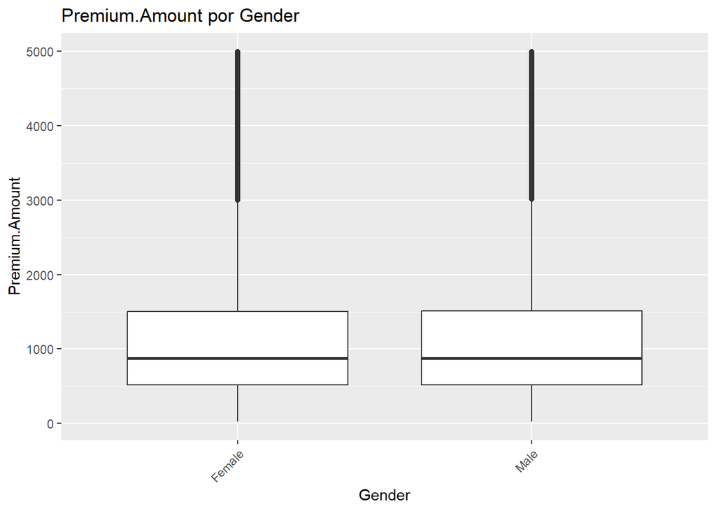

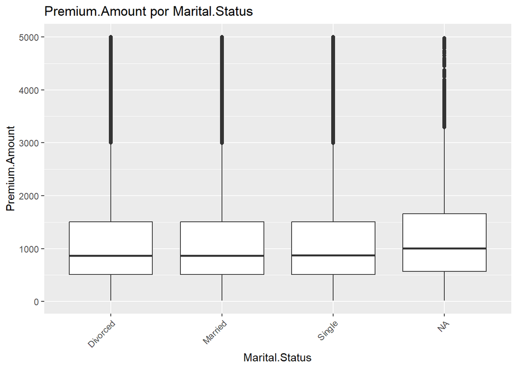

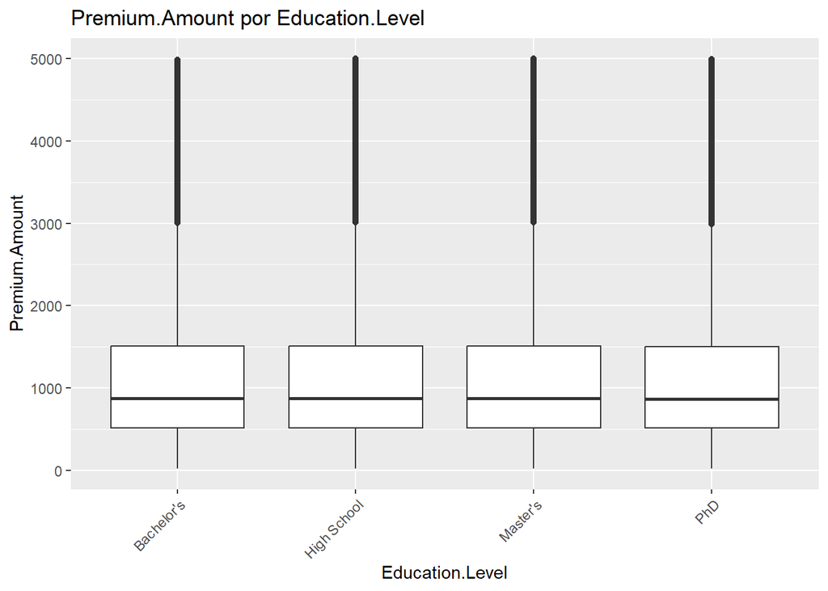

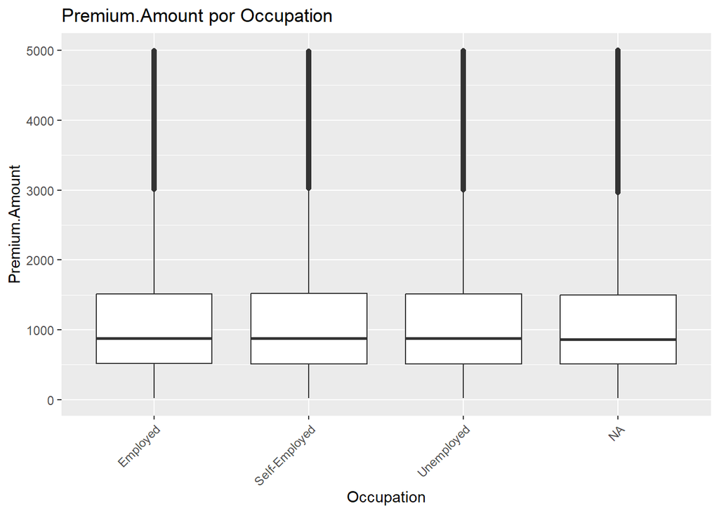

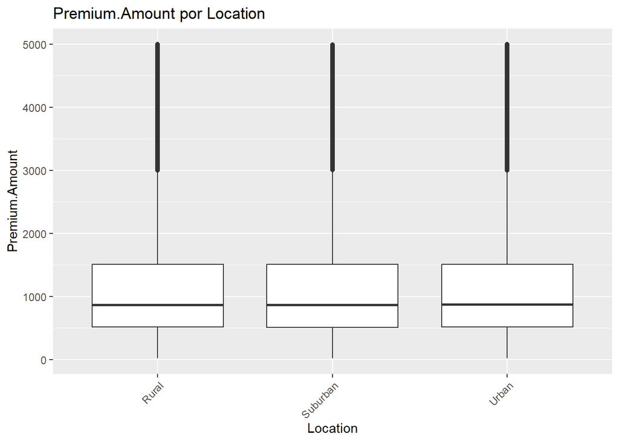

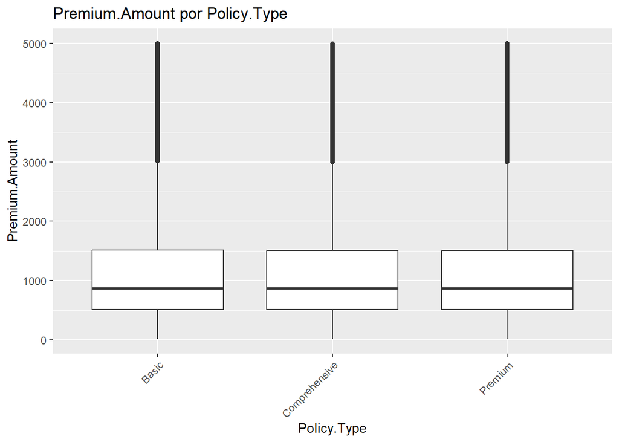

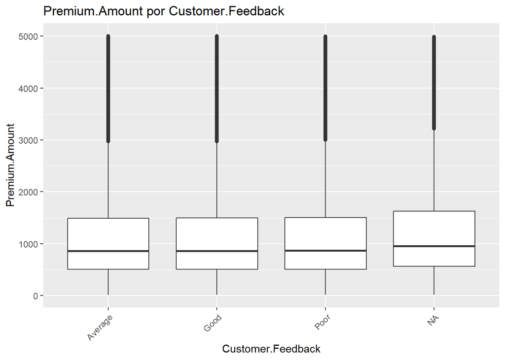

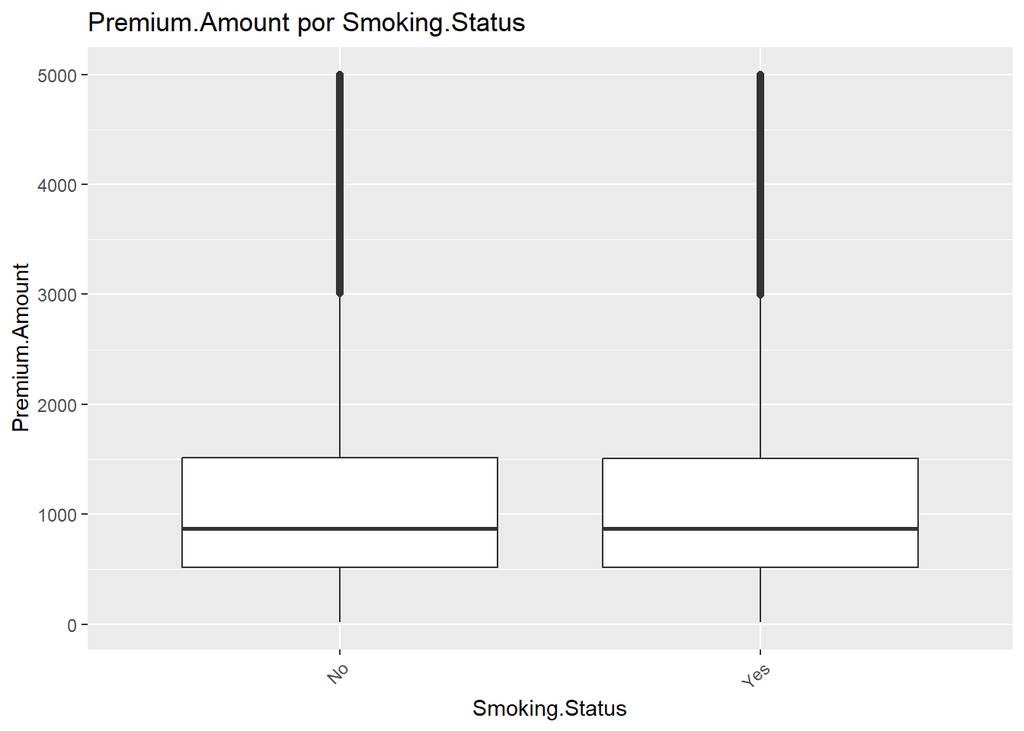

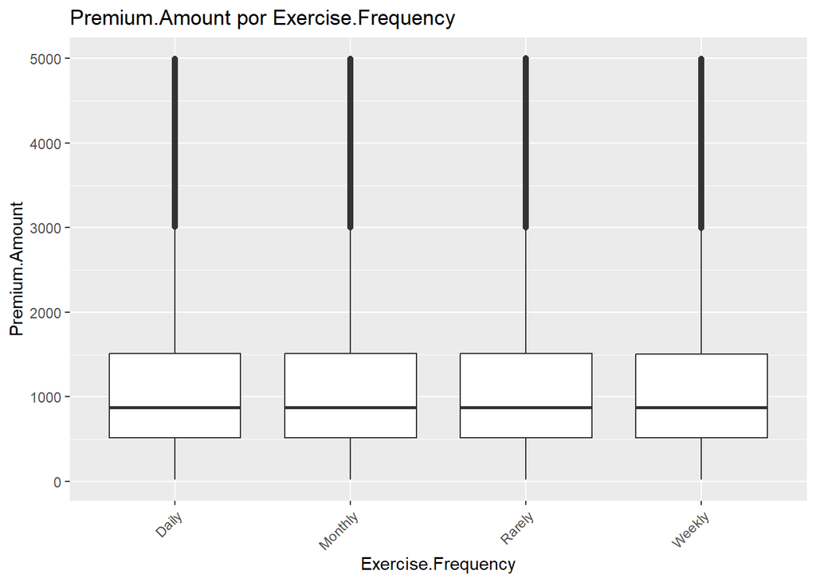

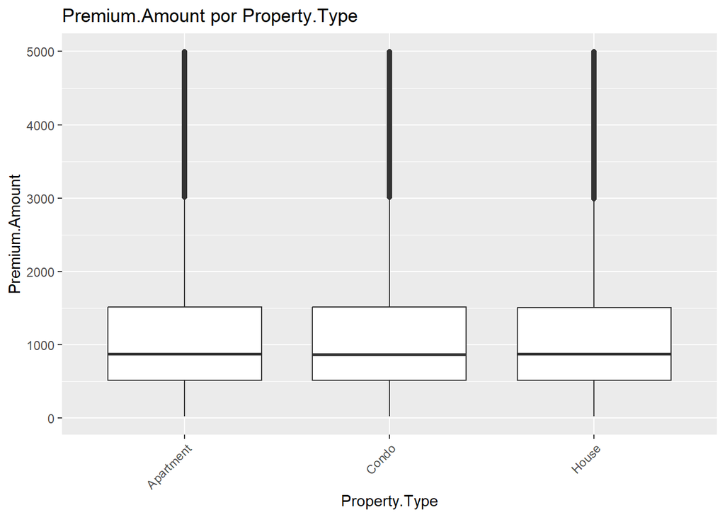

```r
for (v in categorical_vars) {
    p <- ggplot(df, aes(x = .data[[v]], y = Premium.Amount)) +
        geom_boxplot() +
        labs(title = paste("Premium.Amount por", v)) +
        theme(axis.text.x = element_text(angle = 45, hjust = 1))
    print(p)
}
```